# The Effect of Vitamin C on Tooth Growth in Guinea Pigs

Simin Talebpour

## Overview

In this project I want to analyze the effect of vitamin C on tooth growth in guinea pigs using ToothGrowth data in the R datasets package. First I’ll perform some basic exploratory data analyses, and then use hypothesis tests to compare tooth growth by supplement type and dose level.

## Exploratory data analyses

```
## 'data.frame':    60 obs. of  3 variables:
##  $ len : num  4.2 11.5 7.3 5.8 6.4 10 11.2 11.2 5.2 7 ...
##  $ supp: Factor w/ 2 levels "OJ","VC": 2 2 2 2 2 2 2 2 2 2 ...
##  $ dose: num  0.5 0.5 0.5 0.5 0.5 0.5 0.5 0.5 0.5 0.5 ...
```

```
## [1] 0.5 1.0 2.0
```

ToothGrowth data includes 60 observations of 3 variables:  
**len**: numeric variable - tooth length  
**supp**: factor variable with 2 levels: “OJ”( Orange Juice) and “VC”(Vitamin C)  
**dose**: numeric valriable - Dose in milligrams/day  
Each animal received one of three dose levels of vitamin C (0.5, 1, and 2 mg/day) by one of two delivery methods, orange juice or ascorbic acid (a form of vitamin C and coded as VC). The responseis the length of odontoblasts (cells responsible for tooth growth) in 60 guinea pigs.

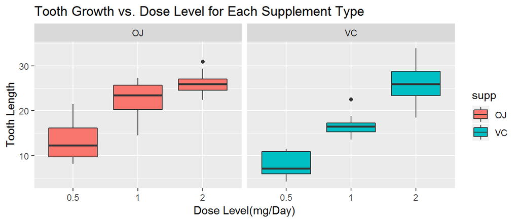

Looking at box plots, I can say by increaing dosage, tooth growth increases for both delivery method(orange juice and Vitamin C).

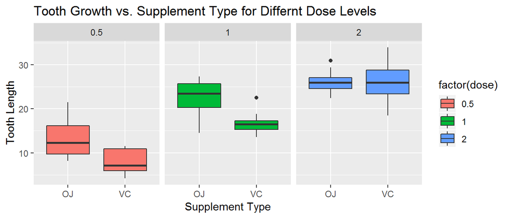

For lower dosages(0.5, 1) orange juice has been more effective, but for dosage = 2, we can’t make a conclusion.

## Hypothesis Tests

#### Hypothesis 1: The supplement type doesn’t effect on the tooth growth

```
##
##  Welch Two Sample t-test
##
## data:  len by supp
## t = 1.9153, df = 55.309, p-value = 0.06063
## alternative hypothesis: true difference in means is not equal to 0
## 95 percent confidence interval:
##  -0.1710156  7.5710156
## sample estimates:
## mean in group OJ mean in group VC
##         20.66333         16.96333
```

p-value(0.06) > significant value(0.05),so I fail to reject the null hypothesis.

#### Hypothesis 2: The dose levels ‘1’ and ‘2’ have the same effect on the tooth growth

```
##
##  Welch Two Sample t-test
##
## data:  len by dose
## t = -4.9005, df = 37.101, p-value = 1.906e-05
## alternative hypothesis: true difference in means is not equal to 0
## 95 percent confidence interval:
##  -8.996481 -3.733519
## sample estimates:
## mean in group 1 mean in group 2
##          19.735          26.100
```

P-value(1.906e-05) < significance value(0.05), so I reject the null hypothesis. Tooth growth is not the same for dose = 1 and dose = 2.

#### Hypothesis 3: The dose levels ‘1’ and ‘0.5’ have the same effect on the tooth growth

```
##
##  Welch Two Sample t-test
##
## data:  len by dose
## t = -6.4766, df = 37.986, p-value = 1.268e-07
## alternative hypothesis: true difference in means is not equal to 0
## 95 percent confidence interval:
##  -11.983781  -6.276219
## sample estimates:
## mean in group 0.5   mean in group 1
##            10.605            19.735
```

P-value(1.268e-07) < significance value(0.05), so I reject the null hypothesis. Tooth growth is not the same for dose = 1 and dose = 0.5.

#### Hypothesis 4: The dose levels ‘2’ and ‘0.5’ have the same effect on the tooth growth

```
##
##  Welch Two Sample t-test
##
## data:  len by dose
## t = -11.799, df = 36.883, p-value = 4.398e-14
## alternative hypothesis: true difference in means is not equal to 0
## 95 percent confidence interval:
##  -18.15617 -12.83383
## sample estimates:
## mean in group 0.5   mean in group 2
##            10.605            26.100
```

P-value(4.398e-14) < significance value(0.05), so I reject the null hypothesis. Tooth growth is not the same for dose = 2 and dose = 0.5.

## Conclusion

I investigated ToothGrowth dataset to see if there is any differnce in guinea pig’s tooth growth based on the type and dose level of vitamin C supplement they recieved. To naswer this question I performed four independent two-sample t-tests assuming the followings:  
- The two samples in each test are independent.  
- The two samples in each test follow normal distributions.  
- The two samples in each test have differnt variance.

**Results:**  
The supplement type doesn’t effect the tooth growth, however the extra dose increases the tooth growth.